# chapter3.Rmd

Kevin Sandeman

15 november 2017

# RStudio Exercise 3

*This week datawrangling, logistic regression, odds ratio and prediction have been central in this course.*

## Read the joined student alcohol consumption data

```r
data_url <- "http://s3.amazonaws.com/assets.datacamp.com/production/course_2218/datasets/alc.txt"
alc <-read.table(data_url, sep=",", header = TRUE)
dim(alc)
```

```
## [1] 382  35
```

```r
colnames(alc)
```

```
##  [1] "school"     "sex"        "age"        "address"    "famsize"
##  [6] "Pstatus"    "Medu"       "Fedu"       "Mjob"       "Fjob"
## [11] "reason"     "nursery"    "internet"   "guardian"   "traveltime"
## [16] "studytime"  "failures"   "schoolsup"  "famsup"     "paid"
## [21] "activities" "higher"     "romantic"   "famrel"     "freetime"
## [26] "goout"      "Dalc"       "Walc"       "health"     "absences"
## [31] "G1"         "G2"         "G3"         "alc_use"    "high_use"
```

The data consists of 382 observations with the following 35 variables:

1. **school:** student’s school (binary: ‘GP’ - Gabriel Pereira or ‘MS’ - Mousinho da Silveira)
2. **sex:** student’s sex (binary: ‘F’ - female or ‘M’ - male)
3. **age:** student’s age (numeric: from 15 to 22)
4. **address:** student’s home address type (binary: ‘U’ - urban or ‘R’ - rural)
5. **famsize:** family size (binary: ‘LE3’ - less or equal to 3 or ‘GT3’ - greater than 3)
6. **Pstatus:** parent’s cohabitation status (binary: ‘T’ - living together or ‘A’ - apart)
7. **Medu:** mother’s education (numeric: 0 - none, 1 - primary education (4th grade), 2 - " 5th to 9th grade, 3 - " secondary education or 4 - " higher education)
8. **Fedu:** father’s education (numeric: 0 - none, 1 - primary education (4th grade), 2 - " 5th to 9th grade, 3 - " secondary education or 4 - " higher education)
9. **Mjob:** mother’s job (nominal: ‘teacher’, ‘health’ care related, civil ‘services’ (e.g. administrative or police), ‘at_home’ or ‘other’)
10. **Fjob:** father’s job (nominal: ‘teacher’, ‘health’ care related, civil ‘services’ (e.g. administrative or police), ‘at_home’ or ‘other’)
11. **reason:** reason to choose this school (nominal: close to ‘home’, school ‘reputation’, ‘course’ preference or ‘other’)
12. **guardian:** student’s guardian (nominal: ‘mother’, ‘father’ or ‘other’)
13. **traveltime:** home to school travel time (numeric: 1 - <15 min., 2 - 15 to 30 min., 3 - 30 min. to 1 hour, or 4 - >1 hour)
14. **studytime:** weekly study time (numeric: 1 - <2 hours, 2 - 2 to 5 hours, 3 - 5 to 10 hours, or 4 - >10 hours)
15. **failures:** number of past class failures (numeric: n if 1<=n<3, else 4)
16. **schoolsup:** extra educational support (binary: yes or no)
17. **famsup:** family educational support (binary: yes or no)
18. **paid:** extra paid classes within the course subject (Math or Portuguese) (binary: yes or no)
19. **activities:** extra-curricular activities (binary: yes or no)
20. **nursery:** attended nursery school (binary: yes or no)
21. **higher:** wants to take higher education (binary: yes or no)
22. **internet:** Internet access at home (binary: yes or no)
23. **romantic:** with a romantic relationship (binary: yes or no)
24. **famrel:** quality of family relationships (numeric: from 1 - very bad to 5 - excellent)
25. **freetime:** free time after school (numeric: from 1 - very low to 5 - very high)
26. **goout:** going out with friends (numeric: from 1 - very low to 5 - very high)
27. **Dalc:** workday alcohol consumption (numeric: from 1 - very low to 5 - very high)
28. **Walc:** weekend alcohol consumption (numeric: from 1 - very low to 5 - very high)
29. **health:** current health status (numeric: from 1 - very bad to 5 - very good)
30. **absences:** number of school absences (numeric: from 0 to 93)  
    The following grades are related with the course subject, Math or Portuguese:
31. **G1:** first period grade (numeric: from 0 to 20)
32. **G2:** second period grade (numeric: from 0 to 20)
33. **G3:** final grade (numeric: from 0 to 20, output target)
34. **alc_use:** average of ‘Dalc’ and ‘Walc’
35. **high_use:** TRUE if ‘alc_use’ is higher than 2 and FALSE otherwise

## Four interesting variables in the data and for each of them, present your personal hypothesis

I would chose sex, quality of family relationship, going out with friends and the willingness to take higher education as variables for further investigastion. I would believe that male students, that go out a lot would use more alcohol. Willingness to take higher education and a good family relationship could be intuitively associated with low alcohol consumption.

## Numerical and graphical exploration of the distributions of the variables above and their relationships with alcohol consumption (use for example cross-tabulations, bar plots and box plots)

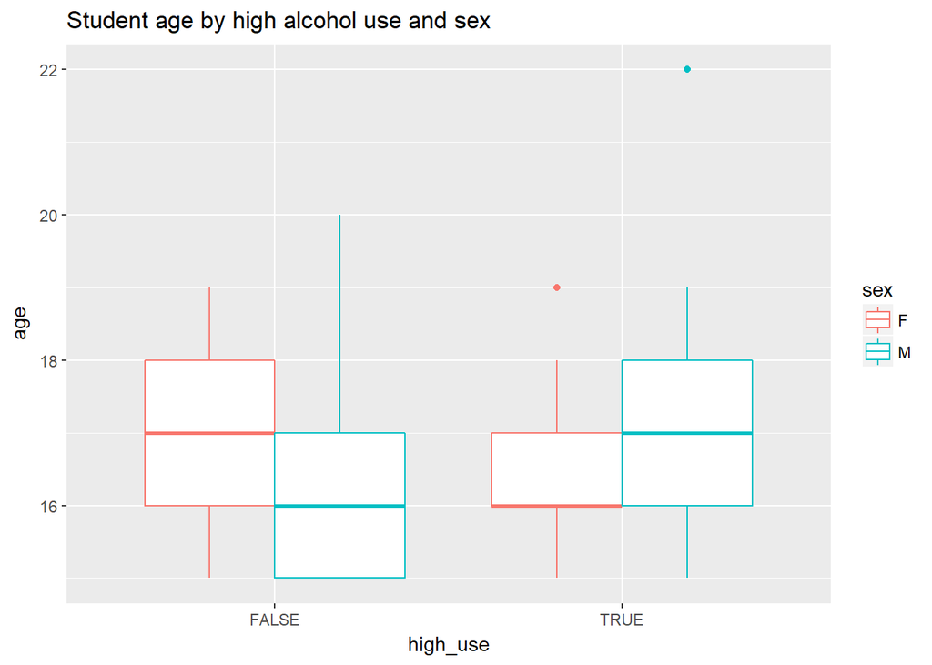

```r
library(tidyr); library(dplyr); library(ggplot2)
ggplot(alc, aes(x = high_use, y = age, col = sex)) + geom_boxplot() + ylab("age") + ggtitle("Student age by high alcohol use and sex")
```

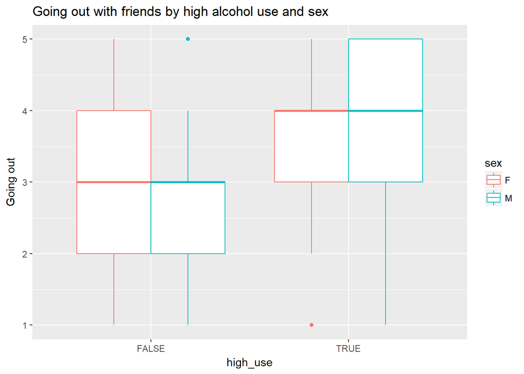

```r
ggplot(alc, aes(x = high_use, y = goout, col = sex)) + geom_boxplot() + ylab("Going out") + ggtitle("Going out with friends by high alcohol use and sex")
```

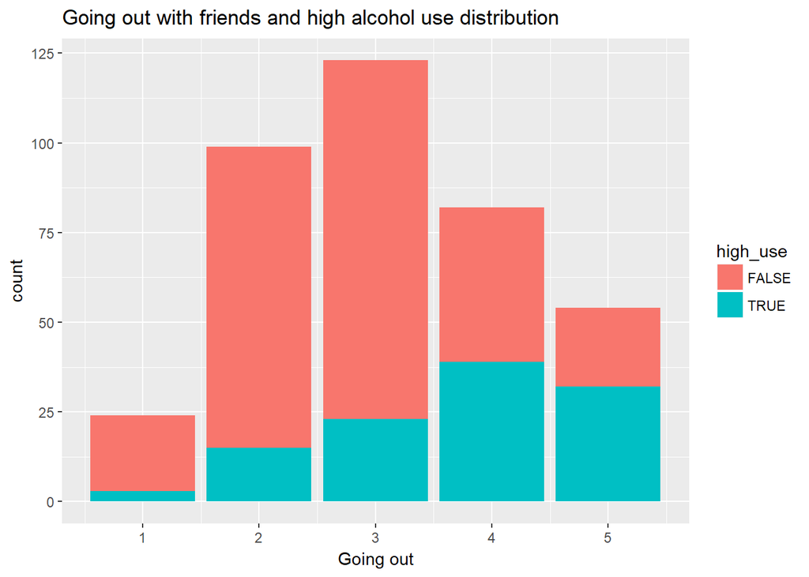

```r
ggplot(data = alc, aes(x =goout, fill = high_use)) + geom_bar() + xlab("Going out") + ggtitle("Going out with friends and high alcohol use distribution")
```

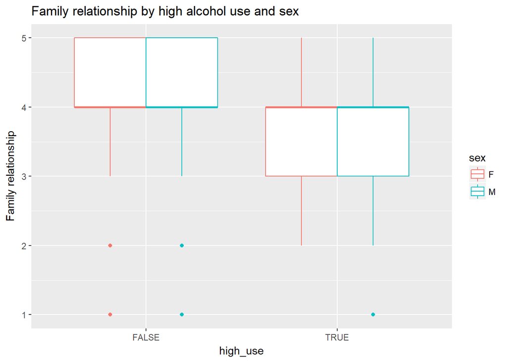

```r
ggplot(alc, aes(x = high_use, y = famrel, col = sex)) + geom_boxplot() + ylab("Family relationship") + ggtitle("Family relationship by high alcohol use and sex")
```

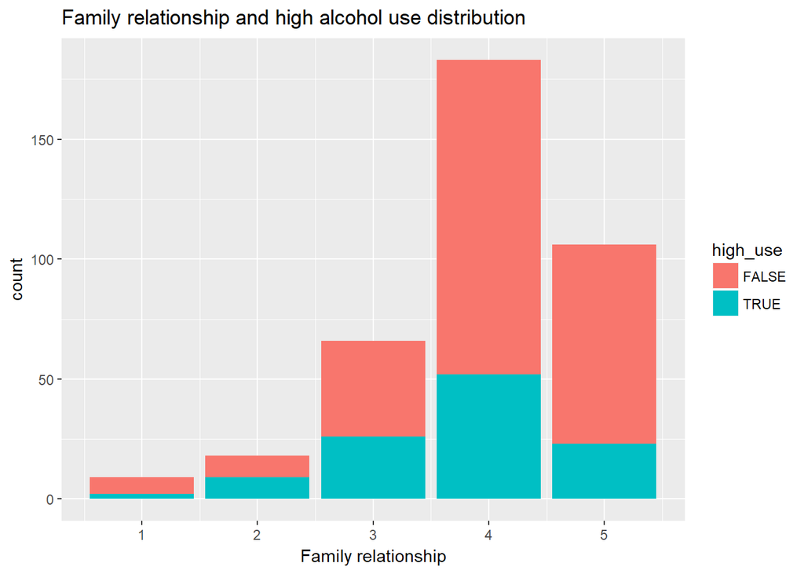

```r
ggplot(data = alc, aes(x = famrel, fill = high_use)) + geom_bar() + xlab("Family relationship") + ggtitle("Family relationship and high alcohol use distribution")
```

```r
table(alc$high_use, alc$sex)
```

```
##
##           F   M
##   FALSE 157 113
##   TRUE   41  71
```

```r
alc %>% group_by(famsup) %>% summarise(count = n(), mean_alc_use = mean(alc_use))
```

```
## # A tibble: 2 x 3
##   famsup count mean_alc_use
##   <fctr> <int>        <dbl>
## 1     no   144     1.954861
## 2    yes   238     1.829832
```

```r
alc %>% group_by(alc_use) %>% summarise(count = n(), mean_goout = mean(goout))
```

```
## # A tibble: 9 x 3
##   alc_use count mean_goout
##     <dbl> <int>      <dbl>
## 1     1.0   144   2.736111
## 2     1.5    68   2.882353
## 3     2.0    58   3.120690
## 4     2.5    42   3.309524
## 5     3.0    32   4.000000
## 6     3.5    17   3.764706
## 7     4.0     9   4.222222
## 8     4.5     3   3.666667
## 9     5.0     9   4.222222
```

```r
library(tidyr); library(dplyr)
table(alc$higher, alc$high_use) %>% prop.table %>% addmargins()*100
```

```
##
##            FALSE       TRUE        Sum
##   no    2.356021   2.356021   4.712042
##   yes  68.324607  26.963351  95.287958
##   Sum  70.680628  29.319372 100.000000
```

In the crosstabulation above between the willingness to pursue higher education (“no”, “yes”) and high use of alcohol (“FALSE”, “TRUE”) the numbers are expressed as percentage of the whole studymaterial. Students having a high alcohol use seem not to pursue higher education in the same proportion as the students that drink less.

## Explore the relationship between your chosen variables and the binary high/low alcohol consumption variable as the target variable

```r
library(tidyr)
alc$famrel <- factor(alc$famrel)
alc$goout <- factor(alc$goout)
m <- glm(high_use ~ alc$famrel + alc$goout + higher + sex, data = alc, family = "binomial")
summary(m)
```

```
##
## Call:
## glm(formula = high_use ~ alc$famrel + alc$goout + higher + sex,
##     family = "binomial", data = alc)
##
## Deviance Residuals:
##     Min       1Q   Median       3Q      Max
## -1.5569  -0.7303  -0.4874   0.7327   2.4733
##
## Coefficients:
##             Estimate Std. Error z value Pr(>|z|)
## (Intercept)  -1.9444     1.2071  -1.611 0.107226
## alc$famrel2   0.3801     1.0768   0.353 0.724127
## alc$famrel3   0.4501     0.9709   0.464 0.642952
## alc$famrel4  -0.3165     0.9489  -0.334 0.738730
## alc$famrel5  -0.9362     0.9710  -0.964 0.334934
## alc$goout2    0.2091     0.6940   0.301 0.763227
## alc$goout3    0.5296     0.6768   0.782 0.433976
## alc$goout4    2.0342     0.6753   3.012 0.002594 **
## alc$goout5    2.4735     0.6968   3.550 0.000385 ***
## higheryes    -0.3391     0.5666  -0.598 0.549523
## sexM          0.9851     0.2635   3.739 0.000185 ***
## ---
## Signif. codes:  0 '***' 0.001 '**' 0.01 '*' 0.05 '.' 0.1 ' ' 1
##
## (Dispersion parameter for binomial family taken to be 1)
##
##     Null deviance: 462.21  on 381  degrees of freedom
## Residual deviance: 378.16  on 371  degrees of freedom
## AIC: 400.16
##
## Number of Fisher Scoring iterations: 4
```

```r
OR <- coef(m) %>% exp
CI <- confint(m) %>% exp
cbind(OR, CI)
```

```
##                     OR      2.5 %    97.5 %
## (Intercept)  0.1430801 0.01029021  1.270211
## alc$famrel2  1.4623806 0.20016974 15.231512
## alc$famrel3  1.5684279 0.27441876 13.984373
## alc$famrel4  0.7286997 0.13357043  6.261852
## alc$famrel5  0.3921018 0.06771719  3.457162
## alc$goout2   1.2325383 0.35085792  5.807814
## alc$goout3   1.6982026 0.50605996  7.820783
## alc$goout4   7.6459609 2.29792372 35.198633
## alc$goout5  11.8638973 3.39834985 56.396606
## higheryes    0.7124103 0.23173686  2.193897
## sexM         2.6782042 1.60825469  4.529032
```

The odds ratios show 2.7 times higher risk for males to have a high alcohol consumption. Also going out frequently (4) to very frequently (5) adds respectively 7.6 and 11.9 times the risk of high alcohol consumption.

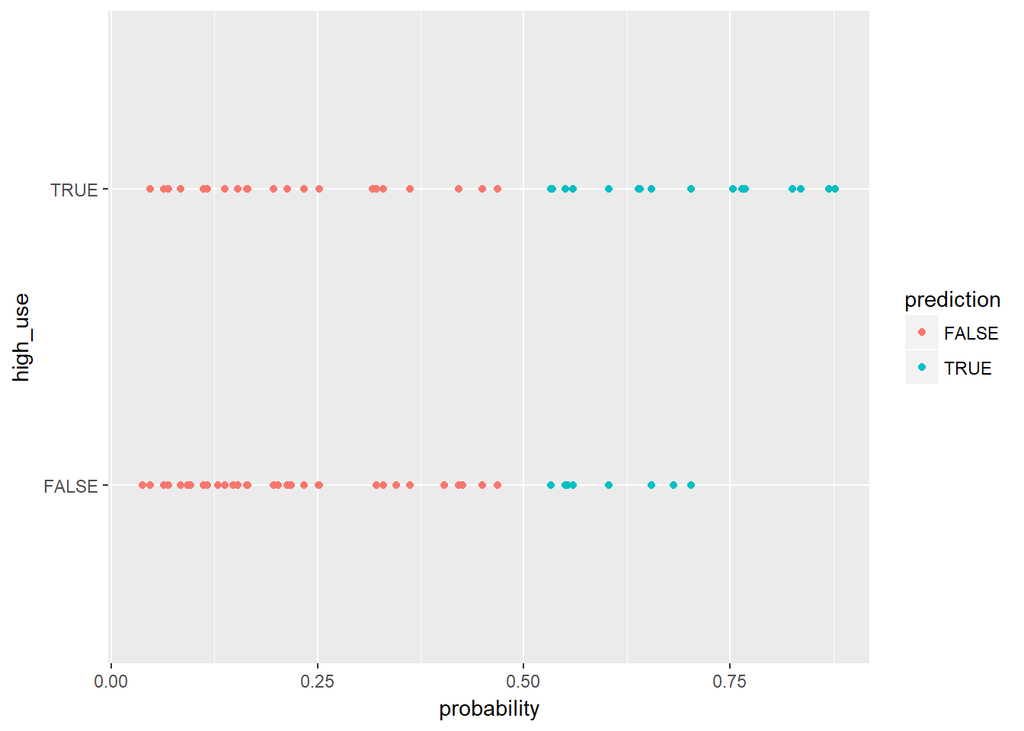

```r
probabilities <- predict(m, type = "response")
alc <- mutate(alc, probability = probabilities)
alc <- mutate(alc, prediction = probability > 0.5)
g <- ggplot(alc, aes(x = probability, y = high_use, col = prediction))
g + geom_point()
```

```r
table(high_use = alc$high_use, prediction = alc$prediction) %>% prop.table() %>% addmargins
```

```
##         prediction
## high_use      FALSE       TRUE        Sum
##    FALSE 0.65445026 0.05235602 0.70680628
##    TRUE  0.14921466 0.14397906 0.29319372
##    Sum   0.80366492 0.19633508 1.00000000
```

The prediction missed 14.9 % true cases of high alcohol use and predicted 5.2 % of high_use, that weren’t high_use cases.

```r
loss_func <- function(class, prob) {
  n_wrong <- abs(class - prob) > 0.5
  mean(n_wrong)
}

loss_func(class = alc$high_use, prob = alc$probability)
```

```
## [1] 0.2015707
```

The prediction of the logistic regression model deviates 20 % of the actual values.

## Bonus 10-fold cross-validation

```r
library(boot)
m <- glm(high_use ~ famrel + goout + higher + sex, data = alc, family = "binomial")
cv <- cv.glm(data = alc, cost = loss_func, glmfit = m, K = 10)
cv$delta
```

```
## [1] 0.2146597 0.2105137
```